# Final Report

Group 5: Megan Lui, Michelle Wong, Yael Yossefy, Dirgh Shah

December 06, 2024

## Introduction

### Scientific Question:

Does the relationship between EtCO2 and AMC behave differently in the presence of relevant medical history?

### Clinical relevance:

Observing the relationship between EtCO2 (end-tidal carbon dioxide) and AMC (area of maximum compression) is crucial to understanding the quality of chest compression during CPR (cardiopulmonary resuscitation), a life-saving procedure during cardiac arrests. Chest compressions are crucial to reviving a patient or achieving ROSC or Return to Spontaneous Circulation, though they requires adequate rate, depth, and location for the best results. However, CPR guidelines are not as precise, as differences in body size and histories of chronic disease can alter the heart’s location. When patients have compression in the aortic root, there is an obstruction of blood flow from the heart and can limit effective perfusion and worsen the prognosis. Compressions over the left ventricle or LV can improve the blood circulation and lead to higher-quality CPR. This relationship between EtCO2 (where higher levels have been shown to correlate with better blood flow from past studies) and AMC may differ dependent on a patient’s history, as these conditions can impact the ventilation-perfusion mismatch or other presenting symptoms.

## Methods

### Design of Study:

This study focuses on 2 primary areas of compression, the left ventricle (LV) and the left ventricle outflow tract (LVOT)/aortic root, and how compression over these AMCs impact EtCO2 levels and whether this impact changes by the CPR patients’ pre existing medical conditions, such as coronary artery disease, congestive hearth failure, chronic kidney disease, diabetes mellitus and myocardial infarction.

### Data set Details:

The data set consists of 129 cases of in-hospital cardiac arrests where transesophageal echocardiography (TEE) imaging was employed during CPR. This advanced imaging technique is used to identify the specific area of the chest targeted for compression to precisely classify the AMC - LV or LVOT.

The dependent variable in the dataset is EtCO2. Measured during CPR, EtCO2 represents levels of exhaled CO2 and serves as a proxy for cardiac output. The primary independent variable is AMC, the area of maximum chest compression and is classified into two categories: left ventricle (LV) and left ventricular outflow tract (LVOT). Additionally, the analysis accounts for medical history, captured through binary indicators for specific conditions such as coronary artery disease (hist1), congestive heart failure (hist2), chronic kidney disease (hist3), diabetes mellitus (hist4), and prior myocardial infarction (hist5).

There are also covariates included in the dataset. These consist of demographic factors like race and gender, the experience level of the TEE operator (such as attending physician, resident, etc.), the type of CPR performed (manual, mechanical, or alternating), and the timing of cardiac arrest (known or approximated). These variables provide a comprehensive overview of the factors that might influence EtCO2 during CPR.

First, the data set underwent pre-processing and cleaning, which included the removal of invalid data entries. The next step involved converting the numeric values flagged as outliers (e.g. placeholder values like 9999) to missing (NA) values and excluding them from the analysis.

### Cohort:

The study cohort consisted of adult patients who had experienced in-hospital cardiac arrest and received CPR where TEE was used. The inclusion criteria required proper TEE imaging data to identify the precise location of AMC and valid measurements of EtCO2 levels. Patients with any significant missing data were excluded. After pre-processing and cleaning, the data set included 106 valid observations (patients) for further analysis.

### Tables Figures Statistics

First, let’s explore the relationship between AMC and EtCO2.

EtCO2 Statistics, grouped by AMC

| Area of Maximum Compression | Min | Q1 | Median | Q3 | Max | Mean | SD | n | N/A |
| --- | --- | --- | --- | --- | --- | --- | --- | --- | --- |
| LV | 7 | 11 | 15 | 18 | 78 | 15.75385 | 8.895278 | 65 | 0 |
| LVOT/Aortic root | 6 | 11 | 12 | 13 | 19 | 12.26829 | 2.711313 | 41 | 0 |

In our summary table above, we see that the mean EtCO2 levels are higher for the Left Ventricle AMC (15.75) than for the Aortic Root AMC (12.27). The same can be said for the median values of EtCO2, which are 15 and 12, respectively.

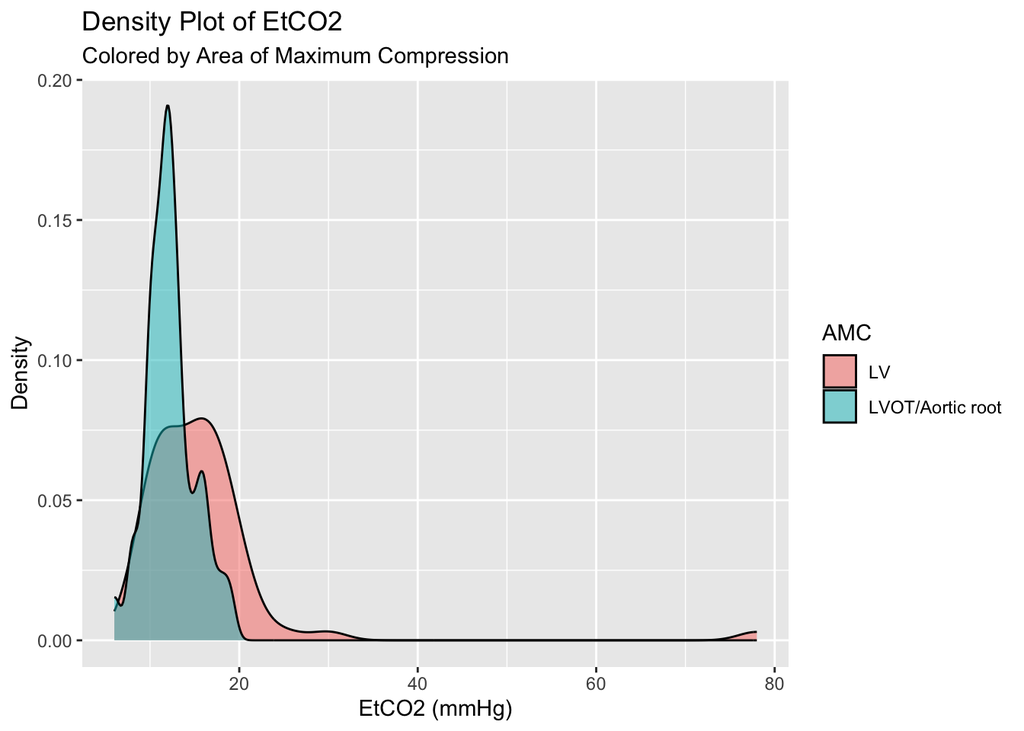

As we can see by the plot above, the EtCO2 levels are centered about a higher value, and have a wider spread for the Left Ventricle AMC than for the Aortic Root AMC, which has a narrower spread and taller peak at a lower value of EtCO2. This is confirmed by the table above, which reports a higher EtCO2 Standard Deviation for the Left Ventricle AMC than the Aortic Root.

Finally, we see all of these findings displayed in our boxplot, of Area of Maximum Compression along the x-axis, and EtCO2 along the y-axis.

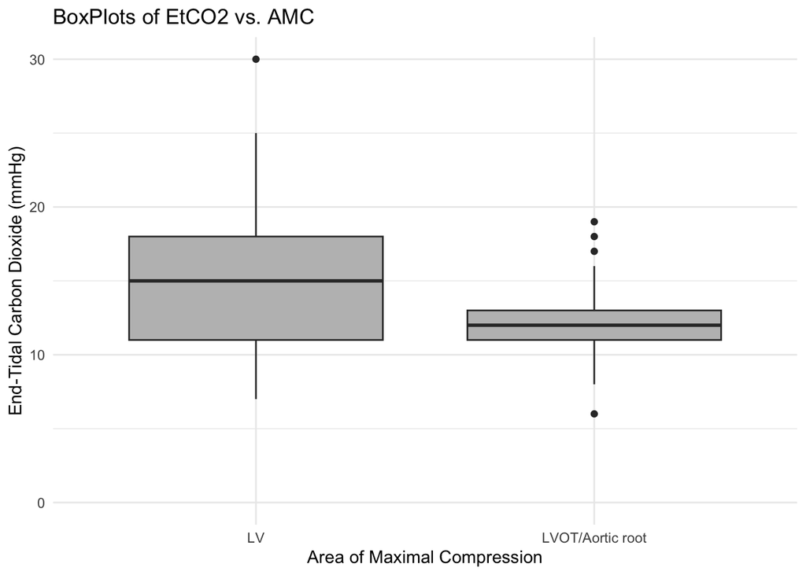

Now let’s explore how history of disease affects this relationships:

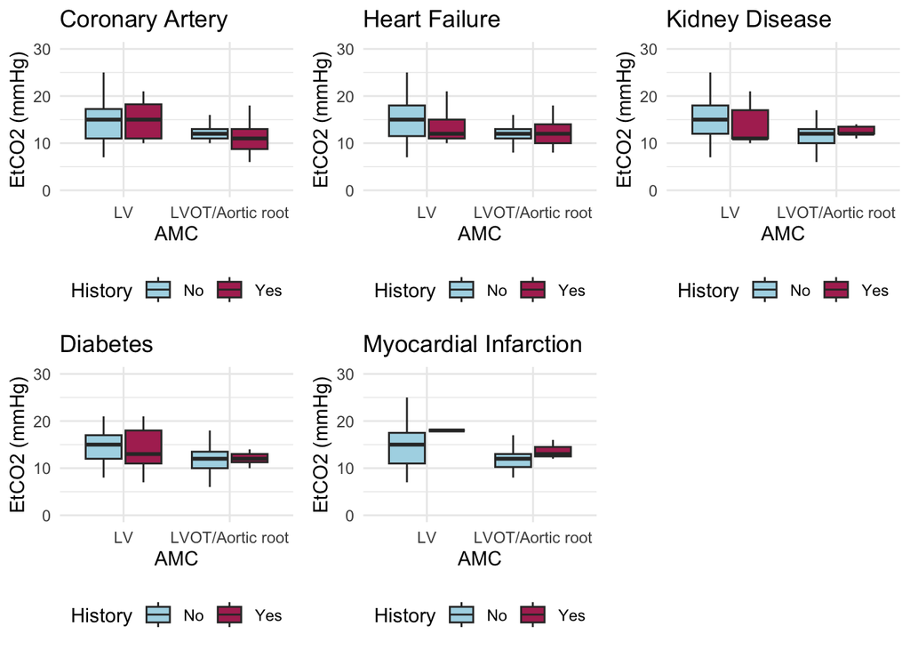

For these plots we removed outliers to visualize the data more clearly. As we can see, there doesn’t seem to be a clear affect on the relationship by any of the individual histories. We can see this by comparing the boxplots to the one earlier (before histories were introduced). We see the same trends, wider boxplots with generally higher values for the “LV” AMC and thinner, lower boxplots for the “LVOT/Aortic Root”. For Myocardial Infarctions we notice very thin boxes for those with a history of the disease, and this is because that of our 106 observations in our cleaned data, there were only 4 cases of Myocardial Infarctions. Thus, there isn’t enough data to reach a conclusion for that plot. In the clean data, there are 20 cases of Coronary Artery Disease, 14 of Heart Failure, 19 of Kidney Disease, and 40 of Diabetes. There are no clear indications that any of these diseases affect the relationship between AMC and EtCO2.

To visualize the density plot of EtCO2, colored by AMC, and wrapped by hist1, Coronary Artery Disease, we see the following:

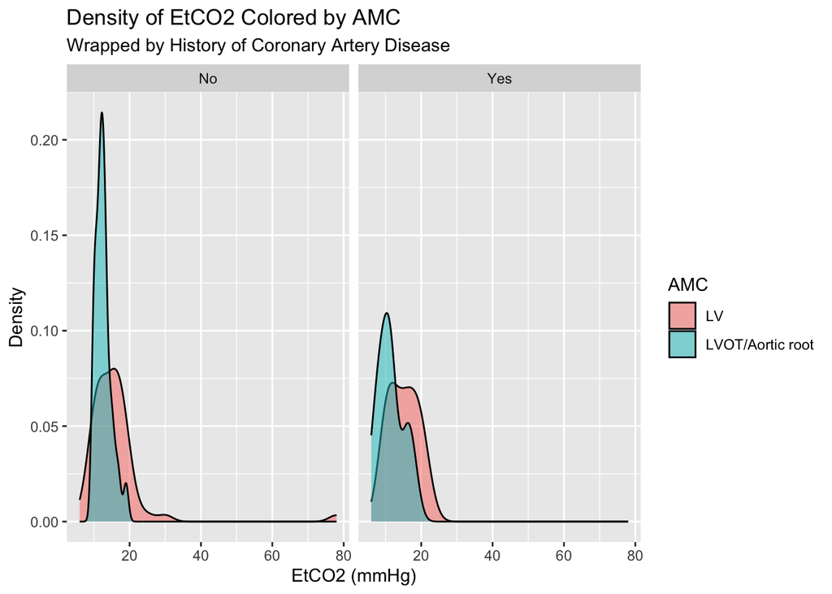

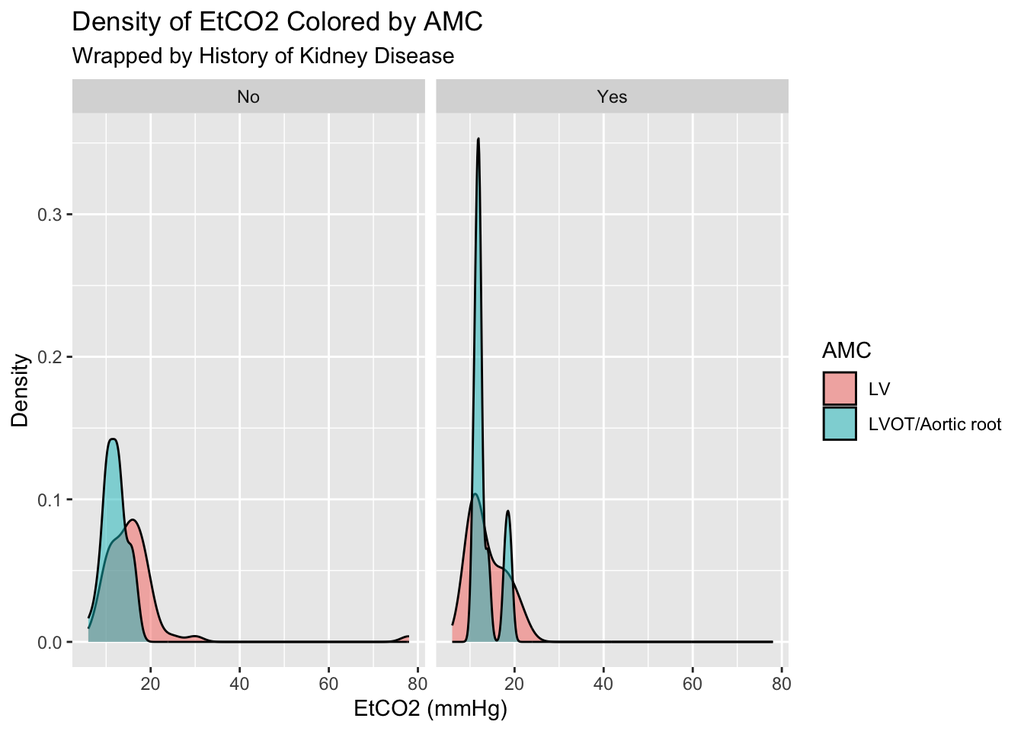

### Box Plot Insights

The box plots of EtCO2 by AMC across the different histories illustrate that patients that have compression over the LV have a larger range of EtCO2 values, as the median values around 15-20 mmHg are compare to the median values of those compressed over the LVOT/aortic root at 10-15 mmHg. Across these comorbidities, both the median and IQRs were similar between patients with and without the medical histories. This may suggest that history has a minimal influence on EtCO2 variability.

### Density Plot Observations

The density plots show that there is a slightly higher concentration of low EtCO2 values (from 5-15 mmHg) in the LVOT/aortic root compared to the LV that has a more even distribution from 10-25 mmHg. For reference, awake and healthy adults normally have a range of 35-45 mmHG of EtCO2. There is no clear shift in these density patterns across the different histories, reinforcing both the statistical findings and box plots that medical history does not significantly affect the EtCO2 levels. Though EtCO2 values are similar between those with and without diseases across both LV and LVOT/aortc root, the proportional density differences in the LVOT/aortic root suggests that perfusion impairments in the area impacts EtCO2 dynamics more than LV. Disease that affect the circulation and gas exchange have a more pronounced effect on the aortic root as well. This leads to higher density proportions at lower EtCO2 value. As the statistical tests show no overall significant effect of disease on EtCo2, these patterns may be due to anatomical sensitivity or local perfusion effects than the impact of history.

#### Density Plot Observations: Understanding the history and EtCO2 levels

Patients with certain pre-existing conditions may already have higher EtCO2 values, independent of compressing the amcs. For those with CAD, CHF, lower EtCO2 values are due to the impaired coronary perfusion, impairing the heart’s ability to effectively pump blood and clear CO2 from the body. Those with CKD, the disease has a much higher proportion of the same EtCO2 value compared to those wihtout CKD, reflecting potential renal dysfunction and thus electrolyte imbalances. This causes body fluid and perfusion to not work as effectively, causing a higher density of patients to have lower EtCO2.

### Analysis Methodology:

A multivariable linear model was implemented to analyse the relationship between EtCO2 level and AMC. Interaction terms between AMC the the medical history variables were used in this model to assess whether the relationship between EtCO2 and AMC varied by the presence of 5 specific pre-existing medical conditions.

The analysis included two models. First being a reduced model, which included only the main effects of AMC and medical history. The second is a full model, which included interaction terms to evaluate whether medical history affected the relationship between EtCO2 and AMC.

An Analysis of Variance (ANOVA) test was used to compare these models and evaluate the contribution of the interaction terms to model fit.

### Rationale:

A linear regression model was implemented based on the assumption that the relationship between EtCO2 and AMC is linear, as CO2 levels in the blood reflect cardiac output which is influnced by the area of compression (LV or LVOT). We assume higher EtCO2 levels when the AMC is LV. This specific approach allows for testing the main effects while including interaction terms to study more complex relationships. The inclusion of these interaction terms is very crucial for identifying whether specific medical histories alter the impact of AMC on EtCO2.

The assumptions include linearity and homoscedasticity, which were checked via residual plots. Independence was checked using the residual plots as well. The normality of residuals was assessed through Q-Q plots. Multicollinearity was evaluated using Variance Inflation Factors (VIF), with all predictors having suitable values (< 5).

This methodological approach addresses potential confounding factors and statistical validity while guaranteeing a thorough investigation of the research question.

### Assumptions Made:

1. Linearity and Homoscedasticity (Constant Variance) The relationship between the predictors and the outcome are linear. This means that changes in the predictors produce proportional changes in the outcome.For homoscedasticity, the variance of the residuals should be constant across all levels of the independent variables.

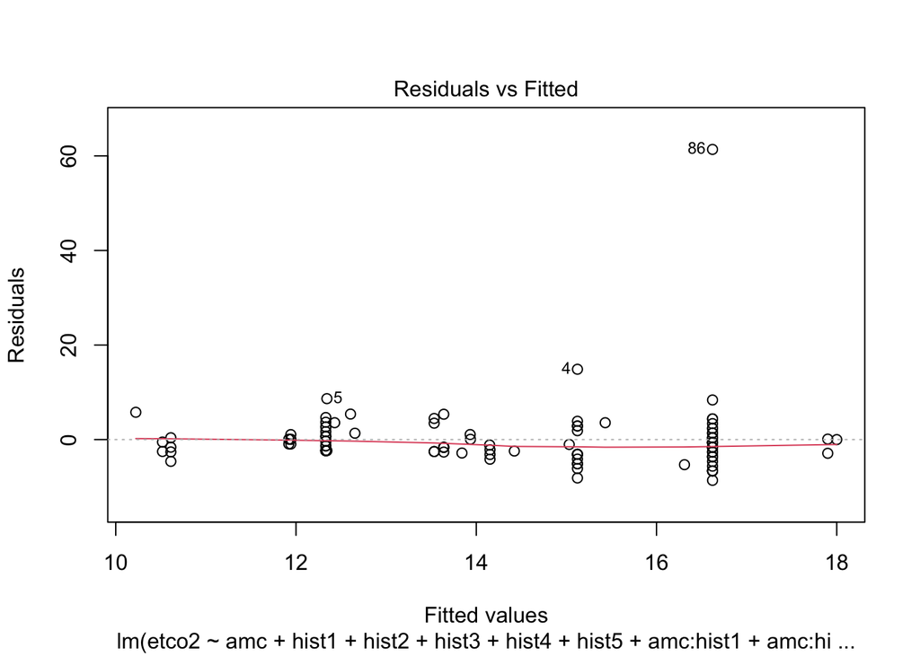

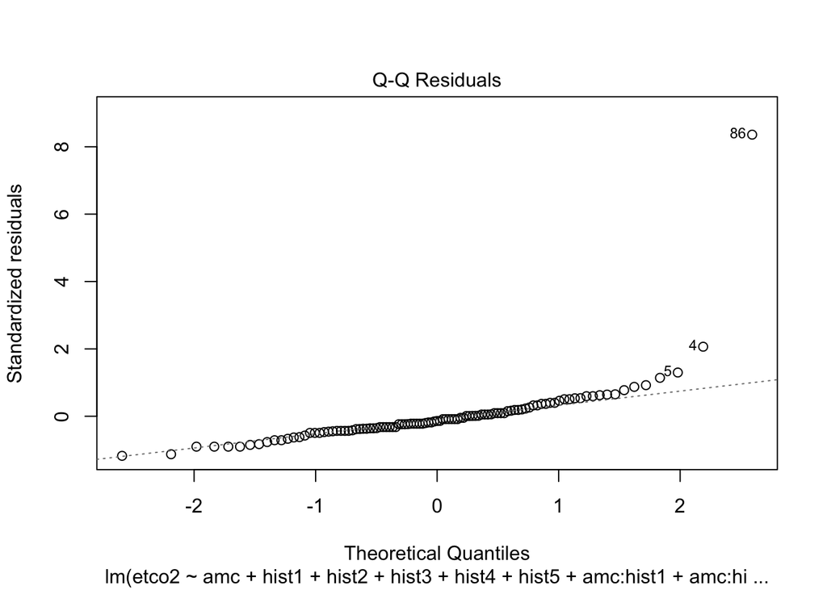

4. No Perfect Multicollinearity: In regression analysis, it is crucial that the independent variables are not highly correlated with one another, as this can make it challenging to isolate the individual effects of each predictor. While this is typically not an issue when the independent variables are categorical or factors in ANOVA, it becomes more relevant in multiple regression.

Variance Inflation Factor (VIF) is commonly used to assess multicollinearity. VIF < 5 indicates acceptable (low) multicollinearity. VIF between 5 and 10 signals moderate multicollinearity and may warrant further investigation. VIF > 10 is considered problematic (high multicollinearity), and such values should generally be avoided.

[output not shown]

### Early linear Regression Model with all possible interaction terms:

Regression Results for ETCO2

term

estimate

std.error

statistic

p.value

significance

(Intercept)

16.6214402

1.194399

13.9161560

0.0000000

***

amcLVOT/Aortic root

-4.2908331

2.044528

-2.0986917

0.0385252

hist1Yes

1.2786827

3.528406

0.3623967

0.7178691

hist2Yes

-2.4691600

3.160923

-0.7811517

0.4366762

hist3Yes

-1.5898467

3.047420

-0.5217025

0.6031046

hist4Yes

-1.4985986

2.087166

-0.7180065

0.4745340

hist5Yes

2.8771585

7.665108

0.3753579

0.7082400

amcLVOT/Aortic root:hist1Yes

-2.9982025

4.537631

-0.6607418

0.5103940

amcLVOT/Aortic root:hist2Yes

2.7652910

5.171067

0.5347621

0.5940770

amcLVOT/Aortic root:hist3Yes

3.2873528

4.488751

0.7323537

0.4657749

amcLVOT/Aortic root:hist4Yes

1.1099354

3.605923

0.3078090

0.7589087

amcLVOT/Aortic root:hist5Yes

-0.6706348

9.070657

-0.0739345

0.9412196

### Early linear Regression Model with all possible interaction terms:

Since the assumptions of ANOVA hold (Independence, multicollinearity, normality of residuals, linearity, and homoscedasticity), we are able to use a linear regression model to examine the relationships between our variables.

## Results

### Exploratory/Descriptive Analysis: Main Statistical Analysis:

The p-value (0.5541) for the F-test is larger than the typical significance threshold of 0.05, meaning the addition of the interaction terms (amc:hist1 and amc:hist3) does not significantly improve the model. The RSS difference between the two models is relatively small (63.984), suggesting that the interactions do not provide a substantial increase in explanatory power.

However, the Residual sum of squares (RSS) which measures the total deviation of the predicted values from the actual values, is lower for Model 2 (5224.8) compared to Model 1 (5288.8), indicating a marginal improvement in fit when the interaction terms are included.

|  | Res.Df | RSS | Df | Sum of Sq | F | Pr(>F) |
| --- | --- | --- | --- | --- | --- | --- |
| 1 | 99 | 5288.817 | NA | NA | NA | NA |
| 2 | 97 | 5224.832 | 2 | 63.98427 | 0.5939401 | 0.5541429 |

## Conclusions

### Main Findings:

Investigating the impact of patient history (including coronary artery disease (CAD), congestive heart failure (CHF), chronic kidney disease (CKD), diabetes mellitus (DM), and myocardial infarcation (MCI)) on EtCO2 levels in both the left ventricle and LVOT/aortic root, our findings revealed that there was no statistically significant difference across all groups. Across the multivariable linear model and ANOVA tests, density plots, and box plots, the results were consistent, suggesting that the patient history does not substantially influence EtCO2 levels.

### Clinical Significance

Our results suggest that EtCO2 levels are not significantly affected by the different histories, though patients with these different chronic disease may have higher EtCO2 values due to already mentioned compensatory mechanisms. Overall, EtCO2 remains a general marker for cardiac output and blood perfusion during CPR, regardless of the patient’s history. As compressions over the LV, compared to LVOT/aortic root, lead to better prognosis with slightly higher EtCO2, optimizing the amc or compression location is crucical for maximizing blood flow and prognosis.

### Limitations and Future Directions

With approximately 106 valid observations after cleaning the data, the are statistically valid. However, having a larger cohort can provide more representative and generalization insight. In addition, there are some measurement constraints, where EtCO2 was measured during CPR, a highly volatile and unpredictable event. There are many dynamic factors and other confounding factors, such as compression rate, depth, and different ventilation that may introduce some variability that the model does not account for. Future studies in this field can explore how other physiological markers, such as blood pressure or ventilation practices, can examine how real time changes in CPR methodologies influence EtCO2 and prognosis of these patients.

Overall, though medical history does not statistically influence the relationship between AMC and EtCO2, those with these chronic conditions may show slightly lower or higher EtCO2 values due to its own physiological mechanisms, highlighting the focus on AMC and optimizing the quality of compression during CPR.

## Citations/References

Baloch K, Rehman Memon A, Ikhlaq U, Umair M, Ansari MI, Abubaker J, Salahuddin N. Assessing the Utility of End-Tidal Carbon Dioxide as a Marker for Fluid Responsiveness in Cardiogenic Shock. Cureus. 2021 Feb 5;13(2):e13164. doi: 10.7759/cureus.13164. PMID: 33692926; PMCID: PMC7938016.

Taghizadieh A, Pouraghaei M, Moharamzadeh P, Ala A, Rahmani F, Basiri Sofiani K. Comparison of end-tidal carbon dioxide and arterial blood bicarbonate levels in patients with metabolic acidosis referred to emergency medicine. J Cardiovasc Thorac Res. 2016;8(3):98-101. doi: 10.15171/jcvtr.2016.21. Epub 2016 Sep 30. PMID: 27777693; PMCID: PMC5075365.

Tepe M, Hakkoymaz H, Kilci Aİ, Gedik MS, Öztürk C, Gökçe MK, Aykan AÇ. Evaluation of the relationship between end-tidal carbon dioxide level and heart failure classification. Rev Assoc Med Bras (1992). 2024 May 20;70(5):e20231499. doi: 10.1590/1806-9282.20231499. PMID: 38775509; PMCID: PMC11110962.

Ölander CH, Vikholm P, Schiller P, Hellgren L. End-Tidal Carbon Dioxide Impacts Brain and Kidney Injury in Experimental Extracorporeal Cardiopulmonary Resuscitation (ECPR). Shock. 2021 Apr 1;55(4):563-569. doi: 10.1097/SHK.0000000000001645. PMID: 32826810.